# Stock Modelling

2024-12-04

Initial Data Loading

```r
wrds <- read.csv('/Users/jasonwang/Desktop/Stat Project 2 Enhanced/mtxntdtwc3ein7sm.csv')
```

Cleaning Process

GOOG IPO 2004, 2014 Google issued a stock split to create a new class of nonvoting stock. Which led to GOOGL and GOOG, GOOGL only had data starting 2014, which led to duplication, and needed cleaning.

Decided to removed META from FAANG, due to IPO date of 2012. And included MSFT due to our initial plan of using MSFT as variable. Using raw price, no adjustments for dividends or splits. (aka google 20 to 1 split not included)

Convert Date to proper format

Removed unneeded columns

Hold off on na removal, due to macro factors

```r
# 'date' is in Date format
wrds$date <- as.Date(wrds$date)
# Remove unnecessary columns
wrds <- wrds %>%
  select(-TRDSTAT, -SHRCLS, -EXCHCD, -PERMNO)

# Filter data for tickers
GOOG <- wrds %>%
  filter(grepl("goog", TICKER, ignore.case = TRUE) & !grepl("googl", TICKER, ignore.case = TRUE)) # Predicting

MSFT <- wrds %>% filter(grepl("msft", TICKER, ignore.case = TRUE)) # FAANG (aang)
AAPL <- wrds %>% filter(grepl("aapl", TICKER, ignore.case = TRUE)) # FAANG (aang)
AMZN <- wrds %>% filter(grepl("amzn", TICKER, ignore.case = TRUE)) # FAANG (aang)
NFLX <- wrds %>% filter(grepl("nflx", TICKER, ignore.case = TRUE)) # FAANG (aang)
```

```r
# Export filtered datasets
write.csv(GOOG, "/Users/jasonwang/Desktop/GOOG_data.csv", row.names = FALSE)
write.csv(MSFT, "/Users/jasonwang/Desktop/MSFT_data.csv", row.names = FALSE)
write.csv(AAPL, "/Users/jasonwang/Desktop/AAPL_data.csv", row.names = FALSE)
write.csv(AMZN, "/Users/jasonwang/Desktop/AMZN_data.csv", row.names = FALSE)
write.csv(NFLX, "/Users/jasonwang/Desktop/NFLX_data.csv", row.names = FALSE)

#3
GOOG <- read.csv('/Users/jasonwang/Desktop/GOOG_data.csv')
MSFT <- read.csv('/Users/jasonwang/Desktop/MSFT_data.csv')
AAPL <- read.csv('/Users/jasonwang/Desktop/AAPL_data.csv')
AMZN <- read.csv('/Users/jasonwang/Desktop/AMZN_data.csv')
NFLX <- read.csv('/Users/jasonwang/Desktop/NFLX_data.csv')

GOOG$date <- as.Date(GOOG$date)
MSFT$date <- as.Date(MSFT$date)
AAPL$date <- as.Date(AAPL$date)
AMZN$date <- as.Date(AMZN$date)
NFLX$date <- as.Date(NFLX$date)
```

Macro Factors Some data is monthly, quarterly and daily.

1. Date format
2. Forward fill - Ensures all dates are present in the stock data by joining with a full date range

Deal with issue of stock dates starting Jan 3rd, created full_stock_dates, which allowed forward fill data from Jan 1st

High_Rate_Env: Binary indicator if Federal Funds Rate > 2.5%

10-Year Treasury Yield less than 1.5%

Recession - GDP decline compared to the previous period

High Unemployment rate > 6 %

```r
# Load CSV files
effective_rate <- read.csv("/Users/jasonwang/Desktop/Stat Project 2 Enhanced/Macro/DFF.csv") # Federal Funds Rate
tenyear <- read.csv("/Users/jasonwang/Desktop/Stat Project 2 Enhanced/Macro/DGS10.csv") # 10-Year Treasury Yield
unemployment <- read.csv("/Users/jasonwang/Desktop/Stat Project 2 Enhanced/Macro/UNRATE.csv") # Unemployment Rate
gdp <- read.csv("/Users/jasonwang/Desktop/Stat Project 2 Enhanced/Macro/GDPC1.csv") # GDP

# Ensure dates are in Date format for all macroeconomic datasets
effective_rate$date <- as.Date(effective_rate$DATE)  # Federal Funds Rate
tenyear$date <- as.Date(tenyear$DATE)                # 10-Year Treasury Yield
unemployment$date <- as.Date(unemployment$DATE)      # Unemployment Rate
gdp$date <- as.Date(gdp$DATE)                        # GDP

# Forward-fill macroeconomic datasets before joining
effective_rate <- effective_rate %>%
  arrange(date) %>%
  tidyr::fill(DFF, .direction = "down")  # Fill Federal Funds Rate

tenyear <- tenyear %>%
  arrange(date) %>%
  tidyr::fill(DGS10, .direction = "down")  # Fill 10-Year Treasury Yield

unemployment <- unemployment %>%
  arrange(date) %>%
  tidyr::fill(UNRATE, .direction = "down")  # Fill Unemployment Rate

gdp <- gdp %>%
  arrange(date) %>%
  tidyr::fill(GDPC1, .direction = "down")  # Fill GDP

# Ensure the stock data has a full date range starting from 2011-01-01
full_stock_dates <- data.frame(date = seq(min(effective_rate$date), max(GOOG$date), by = "day"))

# Extend GOOG stock dataset to include all dates in full_stock_dates
GOOG <- full_stock_dates %>%
  left_join(GOOG, by = "date") %>%
  arrange(date)  # Ensure the dataset is sorted by date

# Join the forward-filled macroeconomic data into the extended GOOG dataset
GOOG <- GOOG %>%
  left_join(effective_rate %>% select(date, FED_FUNDS = DFF), by = "date") %>%
  left_join(tenyear %>% select(date, TEN_YEAR_YIELD = DGS10), by = "date") %>%
  left_join(unemployment %>% select(date, UNEMP_RATE = UNRATE), by = "date") %>%
  left_join(gdp %>% select(date, GDP = GDPC1), by = "date")


# Forward-fill macroeconomic data within the GOOG dataset
GOOG <- GOOG %>%
  arrange(date) %>%  # Ensure data is sorted by date
  tidyr::fill(UNEMP_RATE, GDP, .direction = "down")  # Forward-fill unemployment and GDP

# Add dummy variables to GOOG dataset
GOOG <- GOOG %>%
  mutate(
    # High-Rate Environment: Federal Funds Rate greater than threshold (e.g., 2.5%)
    High_Rate_Env = ifelse(FED_FUNDS > 2.5, 1, 0),

    # Low-Yield Environment: 10-Year Treasury Yield less than threshold (e.g., 1.5%)
    Low_Yield_Env = ifelse(TEN_YEAR_YIELD < 1.5, 1, 0),

    # High Unemployment: Unemployment Rate greater than a threshold (e.g., 6%)
    High_Unemployment = ifelse(UNEMP_RATE > 6, 1, 0),

    # Recession Indicator: GDP lower than the previous period
    Recession = ifelse(GDP < lag(GDP), 1, 0)
  )
```

Combines stock data from multiple tickers (FAANG) AKA AANG + MSFT.

Calculates lagged prices, volumes, and daily returns for analysis.

Lagged RSI (Relative strength index) - Measures stock momentum using a 14-day lookback/ Flags if RSI exceeds thresholds (e.g., >70 or <30)

Traditionally, an RSI reading of 70 or above indicates an overbought condition. A reading of 30 or below indicates an oversold condition.

```r
# Combine FAANG tickers into one dataset
FAANG <- bind_rows(AAPL, AMZN, NFLX, MSFT)

# Process FAANG Data
# Ensure the data is sorted by date within each ticker
FAANG <- FAANG %>%
  arrange(TICKER, date) %>%
  group_by(TICKER) %>%
  mutate(
    # Lag the independent variables
    LagPRC = lag(PRC),         # Lagged Price
    LagVolume = lag(VOL),      # Lagged Volume
    LagOpenPrice = lag(OPENPRC) # Lagged Opening Price
  ) %>%
  ungroup() %>%
  na.omit() # Remove rows with NA values caused by lagging

# Calculate Returns for FAANG
FAANG <- FAANG %>%
  mutate(
    ReturnPRC = (PRC / LagPRC) - 1,  # Current-day return
    LagReturnPRC = lag((PRC / LagPRC) - 1, 1) # Lagged return (one day prior to GOOG)
  )


# Process GOOG Data
GOOG <- GOOG %>%
  arrange(date) %>%
  mutate(
    # Lag the independent variables
    LagPRC = lag(PRC),        # Lagged Price
    LagVolume = lag(VOL),     # Lagged Volume
    LagOpenPrice = lag(OPENPRC) # Lagged Opening Price
  ) %>%
  na.omit() %>% # Remove rows with NA values caused by lagging
  mutate(
    # Calculate returns for all variables
    ReturnPRC = (PRC / LagPRC) - 1,         # Return for Price
    ReturnVolume = (VOL / LagVolume) - 1,   # Return for Volume
    ReturnOpenPrice = (OPENPRC / LagOpenPrice) - 1 # Return for Opening Price
  )

# Add RSI and Lagged Indicators
GOOG <- GOOG %>%
  mutate(
    RSI = RSI(PRC, n = 14),                # Calculate RSI with a 14-day lookback period
    Overbought = ifelse(RSI > 70, 1, 0),  # Overbought condition (RSI > 70)
    Oversold = ifelse(RSI < 30, 1, 0),    # Oversold condition (RSI < 30)
    LagRSI = lag(RSI),                     # Lag RSI
    LagOverbought = lag(Overbought),       # Lag Overbought indicator
    LagOversold = lag(Oversold)            # Lag Oversold indicator
  ) %>%
  na.omit() # Remove rows with NA values caused by lagging
```

Lagging all FAANG, for modelling

```r
# Pivot FAANG lagged returns into columns by ticker
FAANG_Lagged_Returns <- FAANG %>%
  select(date, TICKER, LagReturnPRC) %>%
  spread(key = TICKER, value = LagReturnPRC)

# Rename columns for clarity
colnames(FAANG_Lagged_Returns) <- c("date", "LagReturn_AAPL", "LagReturn_AMZN", "LagReturn_MSFT", "LagReturn_NFLX")

# Merge lagged FAANG returns into GOOG dataset
GOOG <- GOOG %>%
  left_join(FAANG_Lagged_Returns, by = "date")
```

Dummies

Moving average MA50/MA200 - Rolling averages of stock prices over 50 and 200 days.

Bull_Market - Binary indicator if 50-day MA > 200-day MA.

```r
GOOG <- GOOG %>%
  mutate(
    MA50 = lag(rollmean(PRC, k = 50, fill = NA, align = "right")),
    MA200 = lag(rollmean(PRC, k = 200, fill = NA, align = "right"))
  )

GOOG <- GOOG %>%
  mutate(
    Bull_Market = ifelse(MA50 > MA200, 1, 0),
    High_Volatility = ifelse(abs(ReturnPRC) > 0.02, 1, 0)
  )
```

Final Cleaning - Remove any N/A’s

```r
GOOG <- GOOG %>%
  drop_na()
```

split - Splits data into training and testing sets based on date ranges.

```r
# Split FAANG into training and testing sets
train_data <- GOOG %>% filter(date >= "2011-01-01" & date <= "2014-12-31")
test_data <- GOOG %>% filter(date >= "2015-01-01" & date <= "2019-12-31")
```

Linear Regression

```r
# Train the model
model <- lm(PRC ~ LagOversold + LagReturn_AAPL + LagReturn_AMZN + LagReturn_MSFT + LagReturn_NFLX +
              LagVolume + Low_Yield_Env + High_Unemployment + High_Volatility + MA200 + MA50
            , data = train_data)
```

Initially planned to add residual, but due to data leakage. We decided to exclude it from our data set

Two plots, one with confidence band and another without

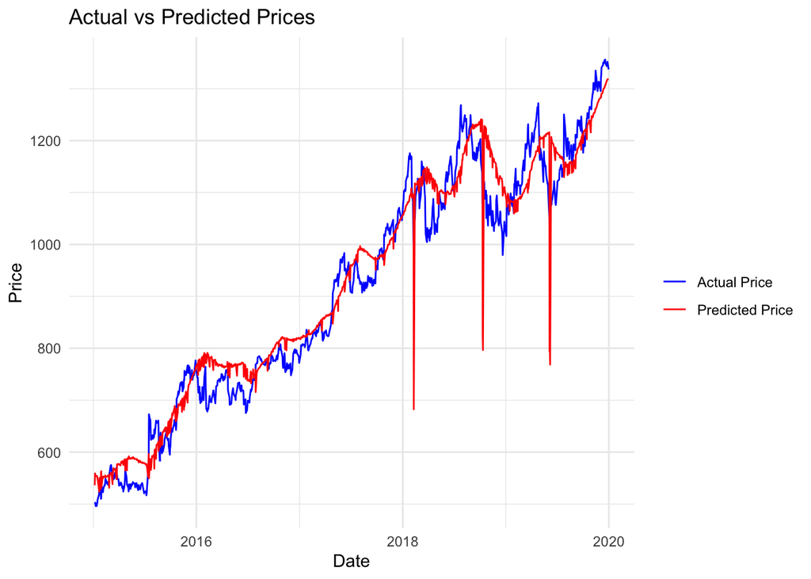

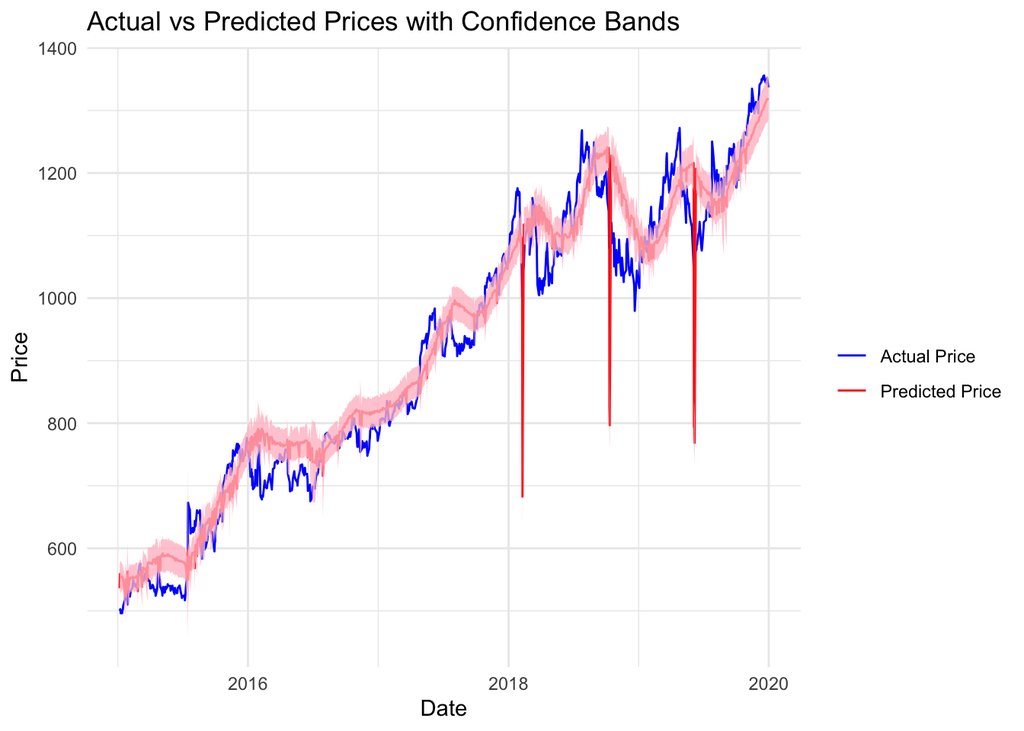

```
## [1] 0.08525336
```

We ended up not using residuals, but maintained this part, and just passed through with same, without the added residual. If we had residuals this would be where we added the residuals into our enhanced model.

```r
# Train a new model using residuals
model_with_residuals <- lm(PRC ~  LagOversold + LagReturn_AAPL + LagReturn_AMZN + LagReturn_MSFT + LagReturn_NFLX +
                         LagVolume + Low_Yield_Env + High_Unemployment + High_Volatility + MA200 + MA50, data = train_data)

summary(model_with_residuals)
```

```
##
## Call:
## lm(formula = PRC ~ LagOversold + LagReturn_AAPL + LagReturn_AMZN +
##     LagReturn_MSFT + LagReturn_NFLX + LagVolume + Low_Yield_Env +
##     High_Unemployment + High_Volatility + MA200 + MA50, data = train_data)
##
## Residuals:
##     Min      1Q  Median      3Q     Max
## -610.17  -37.11   -3.11   44.06  357.83
##
## Coefficients:
##                     Estimate Std. Error t value Pr(>|t|)
## (Intercept)        5.990e+01  2.648e+01   2.262 0.024086 *
## LagOversold       -4.149e+02  1.471e+01 -28.213  < 2e-16 ***
## LagReturn_AAPL     1.011e+02  7.784e+01   1.298 0.194752
## LagReturn_AMZN     2.547e+01  2.149e+02   0.119 0.905689
## LagReturn_MSFT    -1.219e+02  2.618e+02  -0.466 0.641555
## LagReturn_NFLX    -4.357e+01  8.373e+01  -0.520 0.603054
## LagVolume          4.629e-07  3.568e-06   0.130 0.896832
## Low_Yield_Env     -1.859e+01  3.070e+01  -0.606 0.545025
## High_Unemployment -1.716e+01  1.190e+01  -1.443 0.149712
## High_Volatility   -2.198e+01  1.076e+01  -2.044 0.041458 *
## MA200             -1.377e-01  3.701e-02  -3.721 0.000219 ***
## MA50               1.105e+00  2.697e-02  40.965  < 2e-16 ***
## ---
## Signif. codes:  0 '***' 0.001 '**' 0.01 '*' 0.05 '.' 0.1 ' ' 1
##
## Residual standard error: 73.27 on 558 degrees of freedom
## Multiple R-squared:  0.8649, Adjusted R-squared:  0.8622
## F-statistic: 324.7 on 11 and 558 DF,  p-value: < 2.2e-16
```

Test on the test data, to predict

```r
# Predict on test data using the residual-based model
test_data <- test_data %>%
  mutate(Predicted_PRC_With_Residuals = predict(model_with_residuals, newdata = test_data))
```

Trade Strategy

This trade strategy is a buy only, where if it thinks stock will go up, it buys at start of day and sells at end

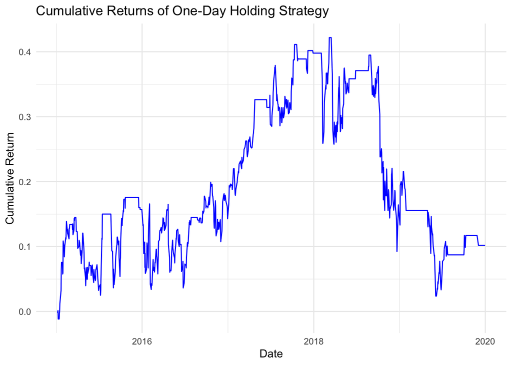

```
## [1] 0.2257881
```

Our Sharpe Ratio = 0.2258

```r
# Load SPY benchmark data
spy_data <- read.csv("/Users/jasonwang/Desktop/Stat Project 2 Enhanced/spy.csv")

# Convert date column
spy_data$date <- as.Date(spy_data$datadate)
```

Checking for Variance Inflation Factor (VIF) Correlation between independent variables are pretty low < 5

```
##       LagOversold    LagReturn_AAPL    LagReturn_AMZN    LagReturn_MSFT
##          1.216691          1.027074          1.184256          1.108840
##    LagReturn_NFLX         LagVolume     Low_Yield_Env High_Unemployment
##          1.117421          1.249727          1.042083          1.517861
##   High_Volatility             MA200              MA50
##          1.053468          2.398103          2.351610
```

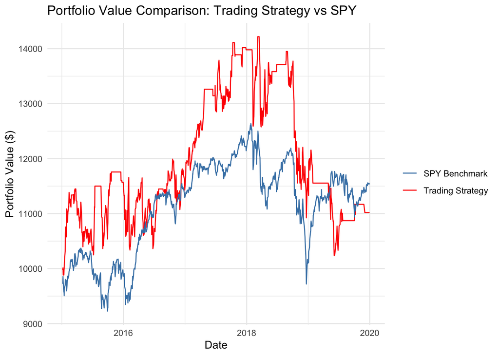

```
## Sharpe Ratio (Our Model): 0.2257881
```

```
## Sharpe Ratio (SPY Benchmark): 0.3199908
```

```
## Cumulative Return (Our Model): 0.1018455
```

```
## Cumulative Return (SPY Benchmark): 0.1533291
```

```
## Information Ratio (Our Model): 0.08355789
```

```
## # A tibble: 5 × 7
##    year mean_daily_return_strategy std_daily_return_stra…¹ sharpe_ratio_strategy
##   <dbl>                      <dbl>                   <dbl>                 <dbl>
## 1  2015                  0.000811                  0.0122                 1.05
## 2  2016                  0.0000258                 0.0132                 0.0309
## 3  2017                  0.00105                   0.00772                2.16
## 4  2018                 -0.000852                  0.0158                -0.856
## 5  2019                 -0.000206                  0.00920               -0.355
## # ℹ abbreviated name: ¹std_daily_return_strategy
## # ℹ 3 more variables: mean_daily_return_spy <dbl>, std_daily_return_spy <dbl>,
## #   sharpe_ratio_spy <dbl>
```

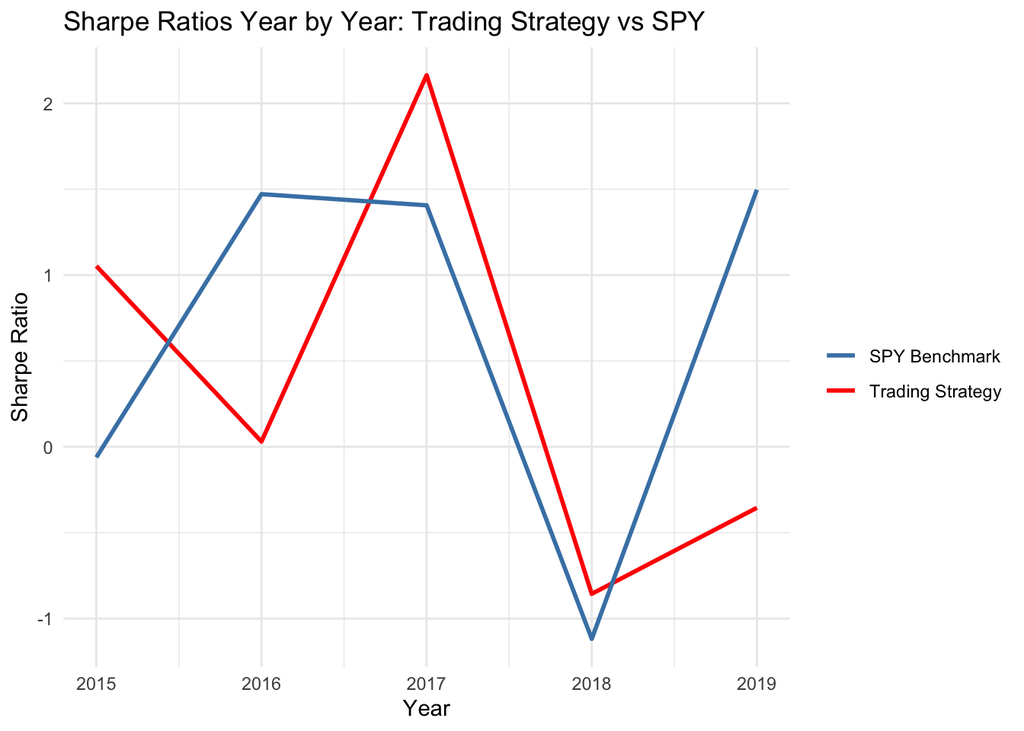

From this we see that our sharpe ratio has not been consistent and on average for period of 2015-2020 we got 0.2258, but ranged from +2 to -0.8

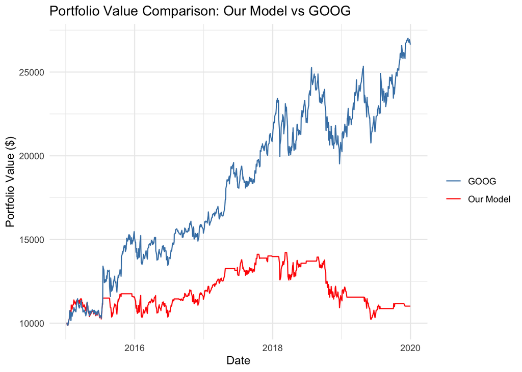

```
## Sharpe Ratio (Trading Strategy): 0.2257881
```

```
## Sharpe Ratio (GOOG): 1.084249
```

```
## Cumulative Return (Trading Strategy): 0.1018455
```

```
## Cumulative Return (GOOG): 1.663599
```

```
## Information Ratio (Trading Strategy vs GOOG): -0.7480226
```